```python
import pandas as pd
import matplotlib.pyplot as plt
```

## Dataset iz područja osiguranja, želite se upoznati s podacima i neke podatke grafički prikazati

## Univarijantna analiza - analiza jedne varijable kako biste vidjeli njenu distribuciju i možebitne anomalije (numerička, kategorička)

# Razumijevanje distribucije vaših podataka prvi je korak u odabiru pravog algoritma i primjeni odgovarajućih tehnika pred-obrade (pre-processing).

### Mnogi klasični statistički i linearni algoritmi pretpostavljaju da su podaci (ili barem greške/reziduali) normalno distribuirani kako bi njihove matematičke pretpostavke i statističke procjene bile valjane i efikasne.

```python
osiguranici = pd.read_csv ("osiguranici.csv")
```

```python
osiguranici.head()
```

|  | City | Gender | Age | Income | Illness |
| --- | --- | --- | --- | --- | --- |
| 0 | Dallas | Male | 41 | 40367.0 | No |
| 1 | Dallas | Male | 54 | 45084.0 | No |
| 2 | Dallas | Male | 42 | 52483.0 | No |
| 3 | Dallas | Male | 40 | 40941.0 | No |
| 4 | Dallas | Male | 46 | 50289.0 | No |

```python
osiguranici.info()
```

```
<class 'pandas.core.frame.DataFrame'>
RangeIndex: 150000 entries, 0 to 149999
Data columns (total 5 columns):
 #   Column   Non-Null Count   Dtype
---  ------   --------------   -----
 0   City     150000 non-null  object
 1   Gender   150000 non-null  object
 2   Age      150000 non-null  int64
 3   Income   150000 non-null  float64
 4   Illness  150000 non-null  object
dtypes: float64(1), int64(1), object(3)
memory usage: 5.7+ MB
```

```python
osiguranici.describe()
```

|  | Age | Income |
| --- | --- | --- |
| count | 150000.000000 | 150000.000000 |
| mean | 44.950200 | 91252.798273 |
| std | 11.572486 | 24989.500948 |
| min | 25.000000 | -654.000000 |
| 25% | 35.000000 | 80867.750000 |
| 50% | 45.000000 | 93655.000000 |
| 75% | 55.000000 | 104519.000000 |
| max | 65.000000 | 177157.000000 |

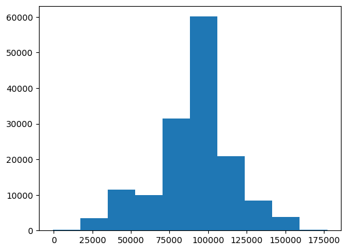

```python
plt.hist (osiguranici.Income)
```

## Uz prikaz osnovnog histograma možemo koristiti različite parametre - pogledati dokumentaciju

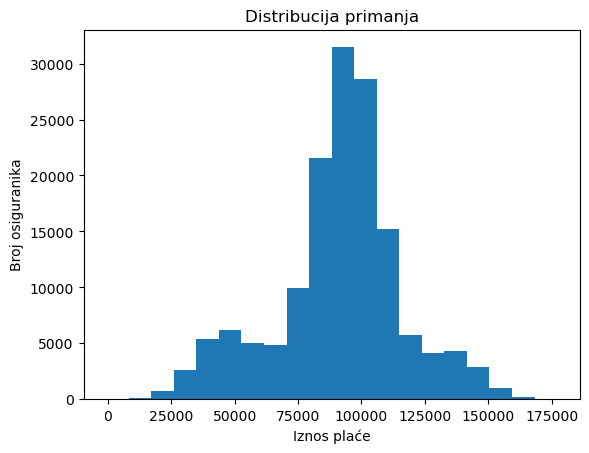

```python
plt.hist (osiguranici.Income, bins = 20)
plt.xlabel("Iznos plaće")
plt.ylabel ("Broj osiguranika")
plt.title ("Distribucija primanja")
```

## hist - naredba za prikaz histograma. Histogram je grafički prikaz u kojem se prikazuje distribucija jedne numeričke varijable

## Uz statističke mjere koristimo i grafički prikaz kako bismo dobili detaljnije informacije koje ne vidimo iz statističkih mjera.

## Histogram je preporučljivo napraviti za sve numeričke varijable koje smatramo važnima

## Kako se zove distribucija prikazana gornjim grafikonom?

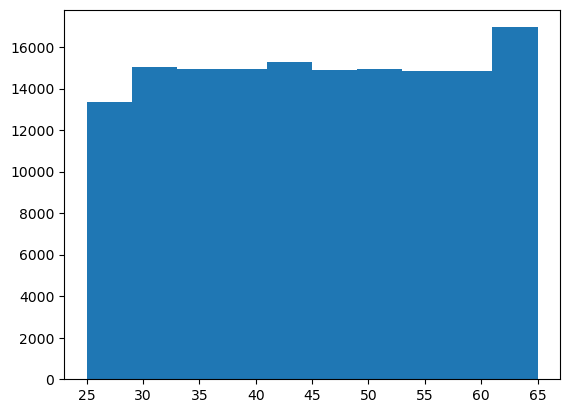

```python
plt.hist (osiguranici.Age)
```

## Tko su klijenti ove osiguravateljske kuće, gledajući njihovu dob?

## Tipovi distribucije podataka:

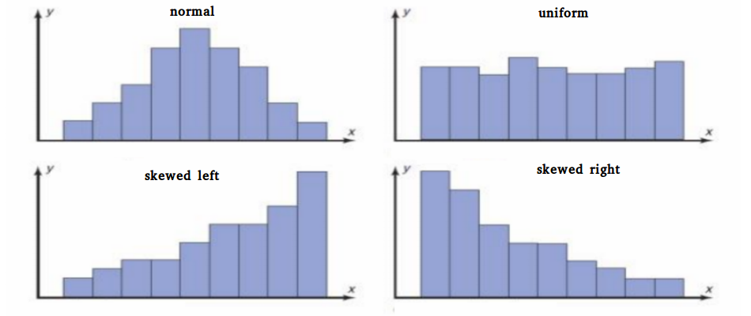

## Proučavamo distribucije podataka kako bismo otkrili postoje li ekstremne vrijednosti, iskrivljenost ili greške. Određeni ML algoritmi su jako osjetljivi na ekstremne vrijednosti, a ponekad radimo i transformacije podataka kako bismo anulirali iskrivljenost (log transformacija, normalizacija, standardizacija)

## O tome detaljnije u drugim lekcijama

# **Zadatak 1**

## učitajte notebook sa zadnjeg predavanja ili otvorite novi u kome ćete učitati dataset Titanic

## Napravite histograme za varijable "Age" i "Fare"

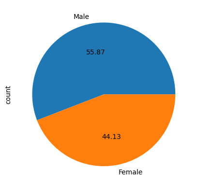

```python
osiguranici['Gender'].value_counts().plot(kind='pie', autopct='%.2f')
```

## univarijantna analiza kategoričke varijable spol korištenjem pie grafikona, autopct parametar omogućuje računanje postotka

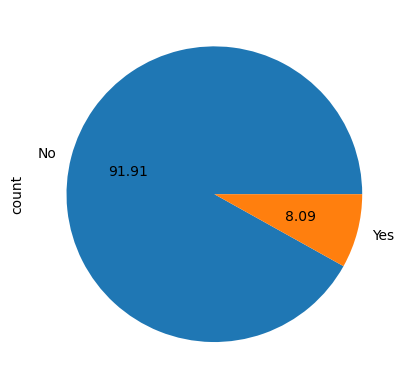

```python
osiguranici['Illness'].value_counts().plot(kind='pie', autopct='%.2f')
```

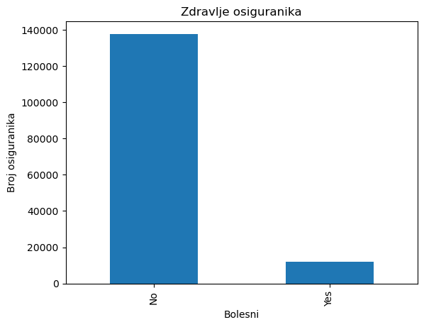

```python
osiguranici['Illness'].value_counts().plot(kind='bar')
plt.xlabel("Bolesni")
plt.ylabel ("Broj osiguranika")
plt.title ("Zdravlje osiguranika")
```

## univarijantna analiza kategoričke varijable korištenjem bar grafikona

# **Zadatak 2**

## na Titanic datasetu napraviti sljedeće grafikone

## Bar grafikon za razred putovanja, promijenite boju stupaca iz plave u neku drugu (pogledati dokumentaciju)

```
array([<Axes: title={'center': 'Female'}>,
       <Axes: title={'center': 'Male'}>], dtype=object)
```

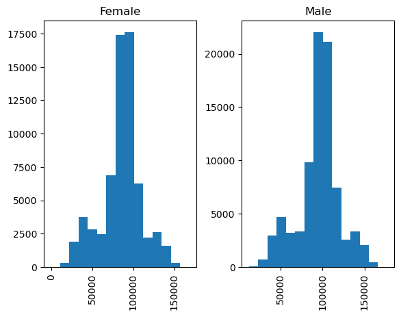

```python
osiguranici["Income"].hist(by = osiguranici["Gender"], bins = 15)
```

## Histogram koji prikazuje distribuciju primanja, ali ovaj put podijeljeno po spolu (za razliku od prvog histograma gdje smo imali histogram primanja za čitavu populaciju)

```
array([<Axes: title={'center': 'No'}>, <Axes: title={'center': 'Yes'}>],
      dtype=object)
```

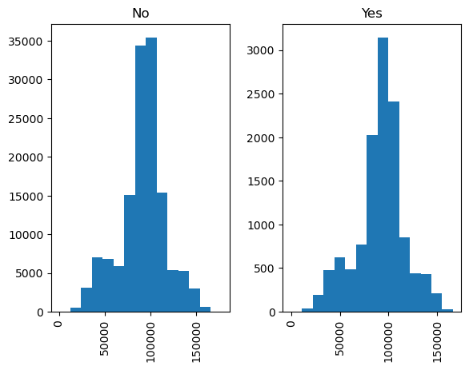

```python
osiguranici["Income"].hist(by = osiguranici["Illness"], bins = 15)
```

## Koja je razlika u primanjima između bolesnih i zdravih osoba?

# **Zadatak 3**

## Na Titanic datasetu odgovoriti na sljedeća pitanja:

## Kako izgleda razdioba starosti po razredu putovanja, gdje su bili mlađi putnici, gdje stariji?

## Gledajući preživjele, prikažite po starosti tko je imao veće šanse za preživljavanje?

## Gledajući preživjele, prikažite po spolu tko je imao veće šanse za preživljavanje?

# Kako se nositi s podacima koji su nakošeni?

### Uobičajene tehnike uključuju:

- Transformacije podataka: Npr. logaritamska transformacija (log()), kvadratni korijen (sqrt()), ili Box-Cox transformacija mogu pomoći da se nakošeni podaci približe normalnoj distribuciji.
- Standardizacija/Normalizacija: Smanjuje utjecaj različitih skala varijabli, ali ne rješava inherentnu nakošenost.
- Korištenje robusnih algoritama: Primjena algoritama kao što su Decision Trees ili Random Forests, koji su manje osjetljivi na oblik distribucije.
- Razumijevanje distribucije vaših podataka prvi je korak u odabiru pravog algoritma i primjeni odgovarajućih tehnika pred-obrade (pre-processing).

```python
osiguranici['Gender'].value_counts().plot(kind='pie', autopct='%.2f')
```

[output not shown]